# Cobb Douglas Profit Maximization

back to [Fan](https://fanwangecon.github.io)'s [Intro Math for Econ](https://fanwangecon.github.io/Math4Econ/), [Matlab Examples](https://fanwangecon.github.io/M4Econ/), or [MEconTools](https://fanwangecon.github.io/MEconTools/) Repositories

In the example here, we will solve a firm optimization problem using a system of linear equations (2 equations and 2 unknowns). The solution method is the same for N inputs with Cobb-Douglas Production Function.

## Firm and Capital and Labor

Assume that the firm can choose capital and labor inputs. At the start of a period, a firm rents capital inputs and combines capital with labor to produce. At the end of the period, the firm sells its output and pays interest rates based on how much capital it rented, and also pays wage. Total wage bill is $L \cdot w$, interest payment is $K \cdot r$ (Here we assume that there is no depreciation of capital, so firm can repay principle by returning capital and just pay interest rate). Profit is denoted by π, period interest rate is r, the price of output is p, the firm makes y units of output, and the production function is Cobb-Douglas: $A \cdot K^\alpha \cdot L^{\beta}$

The profit maximization problem is:

- $\max_{K, L} \left( p\cdot A\cdot K^{\alpha}\cdot L^{\beta}-r\cdot K-w\cdot L \right)$

To find optimal choices, we will assume that $\alpha + \beta < 1$

## Two First Order Conditions

- $\frac{\partial\Pi}{\partial K}=\alpha\cdot p\cdot A\cdot K^{\alpha-1}\cdot L^{\beta}-r$
- $\frac{\partial\Pi}{\partial L}=\beta\cdot p\cdot A\cdot K^{\alpha}\cdot L^{\beta-1}-w$

Components of profit first oder conditions: $MPL$ and $MPK$ are always both positive, but they are decreasing with higher L and higher K respectively. On the other hand, the marginal cost of capital and labor are fixed.

- $\text{MPK} = \alpha \cdot A\cdot K^{\alpha-1}\cdot L^{\beta}$
- $\text{MPL} = \beta\cdot A\cdot K^{\alpha}\cdot L^{\beta-1}$
- $\text{MC}_{K}=r$
- $\text{MC}_{L}=w$

## Log Linearizing Optimality Conditions

To find optimal choices, set the first order conditions you obtained above to be equal to zero.

1. $\alpha\cdot p\cdot A\cdot K^{\alpha-1}\cdot L^{\beta}=r$
2. $\beta\cdot p\cdot A\cdot K^{\alpha}\cdot L^{\beta -1}=w$

A generic system of 2 linear equations and 2 unknowns:

- $\left[ {\begin{array}{cc} a & b \\ d & e \\ \end{array} } \right] \cdot \left[ {\begin{array}{c} x_1 \\ x_2 \end{array} } \right] = \left[ {\begin{array}{cc} a \cdot x_1 + b \cdot x_2 \\ d \cdot x_1 + e \cdot x_2 \\ \end{array} } \right] = \left[ {\begin{array}{c} o \\ p\\ \end{array} } \right]$

Take log of the first order conditions (log linearize), and the two equations above become (Now we can solve for optimal choices using linsolve. Note that log linearizing works regardless of how many terms there are in the cobb-douglas production function):

- $\left[ {\begin{array}{cc} (\alpha-1) & \beta \\ \alpha & (\beta-1) \\ \end{array} } \right] \cdot \left[ {\begin{array}{c} \log(K) \\ \log(L) \end{array} } \right] = \left[ {\begin{array}{cc} (\alpha-1) \cdot \log(K) + \beta \cdot \log(L) \\ \alpha \cdot \log(K) + (\beta-1) \cdot \log(L) \\ \end{array} } \right] = \left[ {\begin{array}{c} \log\left(\frac{r}{\alpha p A}\right) \\ \log\left(\frac{w}{\beta p A}\right)\\ \end{array} } \right]$

We can by hand solve by elementary row operation (linsolve).

## Solving Linear System to find Optimal Choices

The solution to the problem, with parameter values filled in could be obtained like this:

```matlab
clear all
% Parameters
w = 1;
r = 1.05;
p = 5;
alpha = 0.3;
beta = 0.5;
A = 1.0;

%% Matrix Form of linear system
B = [log(r/(p*A*alpha)); log(w/(p*A*beta))];
A = [(alpha-1), beta;alpha, beta-1];
%% Solve linear equations, and then exponentiate
linSolu = exp(linsolve(A, B));
%% Solution was for log(K*) and log(L*), exponentiate to get K* and L*
KOpti = linSolu(1)
```

KOpti = 24.1049

```matlab
LOpti = linSolu(2)
```

LOpti = 42.1835

## Relative Choices

For Cobb-Douglas production functions, how do optimal capital and labor choices relate to each other?

```matlab
syms w r p alpha beta A
% Matrix Form of linear system, same as before
B = [log(r/(p*A*alpha)); log(w/(p*A*beta))];
A = [(alpha-1), beta;alpha, beta-1];
% Solve linear equations, and then exponentiate, same as before
% We can use the simplify command to simplify this solution, get rid of exp and log:
linSolu = simplify(exp(linsolve(A, B)))
```

linSolu =

```matlab
KOpti = linSolu(1)
```

KOpti =

```matlab
LOpti = linSolu(2)
```

LOpti =

```matlab
KOpti/LOpti
```

ans =

[figure not shown]

The expressions from Matlab look a little convoluted, but you will notice a lot of similar terms inside the equation. If you try to simplify things a little bit, you will end up with a simple fraction below, which says the ratio of optimal capital to labor choices is not related to A and p, but determined by the elasticity parameters α and β as well as prices w and r. If wage increases, you will increase the relative demand of capital vs labor. Similarly, if α is higher (each unit of capital is more productive), you will have higher relative demand for capital vs labor as well.

- $\frac{K^*(r, w, A, \alpha, \beta, p)}{L^*(r, w, A, \alpha, \beta, p)} = \frac{w}{r}\cdot \frac{\alpha}{\beta}$

## Choices as a Function of w and r

How do we solve for demand for capital and labor as a function of prices? We can use the code above, except replace numerical values of r and w with symbols. And we can easily derive demand elasticities of prices (which are constant for cobb-douglas production functions)

```matlab
p = 5;
alpha = 0.3;
beta = 0.5;
A = 1.0;
syms w r
% Matrix Form of linear system, same as before
B = [log(r/(p*A*alpha)); log(w/(p*A*beta))];
A = [(alpha-1), beta;alpha, beta-1];
% Solve linear equations, and then exponentiate, same as before
% We can use the simplify command to simplify this solution, get rid of exp and log:
linSolu = simplify(exp(linsolve(A, B)));
% The solution we get here is in terms of fractions, let's write them out:
KOpti = linSolu(1)
```

KOpti =

```matlab
LOpti = linSolu(2)
```

LOpti =

## Own and Cross Price Elasticity

The price of labor and capital both impact the demand for labor as well as for capital.

The elasticity of capital demand with respect to interest rate is the own price elasticity of demand, and the elasticity of demand for capital with respect to wage is the cross price elasticity of demand. Similarly the elasticity of labor demand with respect to wage is the own price elasticity of demand, and the elasticity of labor demand with respect to interest rate is the cross price elasticity of demand.

- If the own and cross price elastcities are in the same direction, then the two inputs are complements.

That is the case here as shown below. This means that with Cobb-Douglas production function labor and capital are complements. When the price of labor, wage increases, the demand for both labor and capital will decrease. If they were substitutes, when labor price increases, capital demand would increase.

Note that the elasticities below are not a function of anything, just a constant. This is a feature of Cobb-Douglas production function, which has constant demand elasticities of demand of inputs with respect to prices (also constant elasticity of output with respect to inputs). This means that capital and labor are always completements.

Note also that earlier on this page, we showed that with changes in prices, relative choice for capital and labor will shift, that does not contradict the fact that they are complements. In another word, as wage increases, firms demand both less capital and less labor, but the effect is greater on labor, leading to higher share of optimal capital choice.

```matlab
% Elasticity of KOpti with respect to prices?
elasKoptiW = simplify((diff(KOpti, w)*w)/KOpti)
```

elasKoptiW =

```matlab
% elasKoptiW = -5/2 for alpha = 0.3 and A = 1.0
elasKoptiR = simplify((diff(KOpti, r)*r)/KOpti)
```

elasKoptiR =

```matlab
% elasKoptiR = -5/2 for alpha = 0.3 and A = 1.0
elasLoptiW = simplify((diff(LOpti, w)*w)/LOpti)
```

elasLoptiW =

```matlab
% elasLoptiW = -7/2 for alpha = 0.3 and A = 1.0
elasLoptiR = simplify((diff(LOpti, r)*r)/LOpti)
```

elasLoptiR =

```matlab
% elasLoptiR = -3/2 for alpha = 0.3 and A = 1.0
```

## Graphical Results for Optimal Choices

We can visualize the optimal choices with these codes below using mesh plot and contour plot

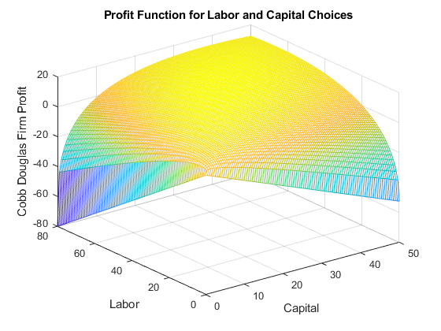

```matlab
% Number of grid points (points along x and y axis)
grid_points = 100;
% Cobb Douglas Utility
alpha = 0.30;
beta = 0.5;

% Budget
p0 = 5; % p0 is price of output
p1 = 1.05; % p1 is r
p2 = 1; % p2 is wage
maxX1 = 50; % this is max domain of capital to plot
maxX2 = 80; % this is max domain of labor to plot
% This generates a vector between 0 and 10 with grid_points number of points
x1 = linspace(0,maxX1,grid_points);
% This generates another vector between 0 and 10 with grid_points number of points
x2 = linspace(0,maxX2,grid_points);
% This creates all possible combinations of the x1 and x2 vectors, fills up the grid
[x1mesh, x2mesh] = meshgrid(x1,x2);
% Evaluate the utility function at all x1 and x2 combination points
PI = p0*(x1mesh.^alpha).*(x2mesh.^beta) - p1.*x1mesh - p2.*x2mesh;
% Graph "hi35ll" using mesh
close all;
figure();
mesh(x1mesh,x2mesh,PI);
% Labeling
xlabel('Capital');
ylabel('Labor');
zlabel('Cobb Douglas Firm Profit');
title('Profit Function for Labor and Capital Choices')
```

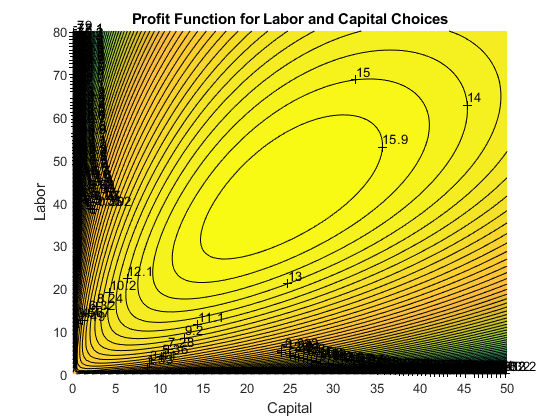

```matlab
%% To see the results more easily, contour plot
figure();
hold on;
% contour plot, 100 is how many contour lines
contour = contourf(x1mesh, x2mesh, PI, 100);
clabel(contour);
% Labeling
xlabel('Capital');
ylabel('Labor');
zlabel('Cobb Douglas Firm Profit');
title('Profit Function for Labor and Capital Choices')
```